# Risk Factor Analysis

## Outcome Variable

**Outcome Variable:** ever_stunted

## Predictor Variables

**Intervention Variable:** vagbrth

**Adjustment Set:**

- arm
- sex
- W_mage
- meducyrs
- feducyrs
- hhwealth_quart
- W_mhtcm
- single
- brthmon
- W_parity
- delta_W_mage
- delta_meducyrs
- delta_feducyrs
- delta_hhwealth_quart
- delta_W_mhtcm
- delta_single
- delta_brthmon
- delta_W_parity

## Stratifying Variables

The analysis was stratified on these variable(s):

- agecat
- studyid
- country

## Data Summary

| agecat | studyid | country | vagbrth | ever_stunted | n_cell | n |
| --- | --- | --- | --- | --- | --- | --- |
| 0-6 months | ki1000108-CMC-V-BCS-2002 | INDIA | 0 | 0 | 20 | 368 |
| 0-6 months | ki1000108-CMC-V-BCS-2002 | INDIA | 0 | 1 | 5 | 368 |
| 0-6 months | ki1000108-CMC-V-BCS-2002 | INDIA | 1 | 0 | 272 | 368 |
| 0-6 months | ki1000108-CMC-V-BCS-2002 | INDIA | 1 | 1 | 71 | 368 |
| 0-6 months | ki1000108-IRC | INDIA | 0 | 0 | 59 | 410 |
| 0-6 months | ki1000108-IRC | INDIA | 0 | 1 | 11 | 410 |
| 0-6 months | ki1000108-IRC | INDIA | 1 | 0 | 301 | 410 |
| 0-6 months | ki1000108-IRC | INDIA | 1 | 1 | 39 | 410 |
| 0-6 months | ki1017093b-PROVIDE | BANGLADESH | 0 | 0 | 143 | 700 |
| 0-6 months | ki1017093b-PROVIDE | BANGLADESH | 0 | 1 | 17 | 700 |
| 0-6 months | ki1017093b-PROVIDE | BANGLADESH | 1 | 0 | 491 | 700 |
| 0-6 months | ki1017093b-PROVIDE | BANGLADESH | 1 | 1 | 49 | 700 |
| 0-6 months | ki1017093c-NIH-Crypto | BANGLADESH | 0 | 0 | 175 | 500 |
| 0-6 months | ki1017093c-NIH-Crypto | BANGLADESH | 0 | 1 | 29 | 500 |
| 0-6 months | ki1017093c-NIH-Crypto | BANGLADESH | 1 | 0 | 257 | 500 |
| 0-6 months | ki1017093c-NIH-Crypto | BANGLADESH | 1 | 1 | 39 | 500 |
| 0-6 months | ki1066203-TanzaniaChild2 | TANZANIA, UNITED REPUBLIC OF | 0 | 0 | 192 | 2367 |
| 0-6 months | ki1066203-TanzaniaChild2 | TANZANIA, UNITED REPUBLIC OF | 0 | 1 | 20 | 2367 |
| 0-6 months | ki1066203-TanzaniaChild2 | TANZANIA, UNITED REPUBLIC OF | 1 | 0 | 2015 | 2367 |
| 0-6 months | ki1066203-TanzaniaChild2 | TANZANIA, UNITED REPUBLIC OF | 1 | 1 | 140 | 2367 |
| 0-6 months | ki1119695-PROBIT | BELARUS | 0 | 0 | 1934 | 16893 |
| 0-6 months | ki1119695-PROBIT | BELARUS | 0 | 1 | 17 | 16893 |
| 0-6 months | ki1119695-PROBIT | BELARUS | 1 | 0 | 14806 | 16893 |
| 0-6 months | ki1119695-PROBIT | BELARUS | 1 | 1 | 136 | 16893 |
| 0-6 months | ki1126311-ZVITAMBO | ZIMBABWE | 0 | 0 | 1086 | 13937 |
| 0-6 months | ki1126311-ZVITAMBO | ZIMBABWE | 0 | 1 | 90 | 13937 |
| 0-6 months | ki1126311-ZVITAMBO | ZIMBABWE | 1 | 0 | 11394 | 13937 |
| 0-6 months | ki1126311-ZVITAMBO | ZIMBABWE | 1 | 1 | 1367 | 13937 |
| 0-6 months | kiGH5241-JiVitA-3 | BANGLADESH | 0 | 0 | 1176 | 27088 |
| 0-6 months | kiGH5241-JiVitA-3 | BANGLADESH | 0 | 1 | 337 | 27088 |

[output cut: 78 more lines]

The following strata were considered:

- agecat: 0-24 months, studyid: ki1000108-CMC-V-BCS-2002, country: INDIA
- agecat: 0-24 months, studyid: ki1000108-IRC, country: INDIA
- agecat: 0-24 months, studyid: ki1017093b-PROVIDE, country: BANGLADESH
- agecat: 0-24 months, studyid: ki1017093c-NIH-Crypto, country: BANGLADESH
- agecat: 0-24 months, studyid: ki1066203-TanzaniaChild2, country: TANZANIA, UNITED REPUBLIC OF
- agecat: 0-24 months, studyid: ki1119695-PROBIT, country: BELARUS
- agecat: 0-24 months, studyid: ki1126311-ZVITAMBO, country: ZIMBABWE
- agecat: 0-24 months, studyid: kiGH5241-JiVitA-3, country: BANGLADESH
- agecat: 0-24 months, studyid: kiGH5241-JiVitA-4, country: BANGLADESH
- agecat: 0-6 months, studyid: ki1000108-CMC-V-BCS-2002, country: INDIA
- agecat: 0-6 months, studyid: ki1000108-IRC, country: INDIA
- agecat: 0-6 months, studyid: ki1017093b-PROVIDE, country: BANGLADESH
- agecat: 0-6 months, studyid: ki1017093c-NIH-Crypto, country: BANGLADESH
- agecat: 0-6 months, studyid: ki1066203-TanzaniaChild2, country: TANZANIA, UNITED REPUBLIC OF
- agecat: 0-6 months, studyid: ki1119695-PROBIT, country: BELARUS
- agecat: 0-6 months, studyid: ki1126311-ZVITAMBO, country: ZIMBABWE
- agecat: 0-6 months, studyid: kiGH5241-JiVitA-3, country: BANGLADESH
- agecat: 0-6 months, studyid: kiGH5241-JiVitA-4, country: BANGLADESH
- agecat: 6-24 months, studyid: ki1000108-CMC-V-BCS-2002, country: INDIA
- agecat: 6-24 months, studyid: ki1000108-IRC, country: INDIA
- agecat: 6-24 months, studyid: ki1017093b-PROVIDE, country: BANGLADESH
- agecat: 6-24 months, studyid: ki1017093c-NIH-Crypto, country: BANGLADESH
- agecat: 6-24 months, studyid: ki1066203-TanzaniaChild2, country: TANZANIA, UNITED REPUBLIC OF
- agecat: 6-24 months, studyid: ki1119695-PROBIT, country: BELARUS
- agecat: 6-24 months, studyid: ki1126311-ZVITAMBO, country: ZIMBABWE
- agecat: 6-24 months, studyid: kiGH5241-JiVitA-3, country: BANGLADESH
- agecat: 6-24 months, studyid: kiGH5241-JiVitA-4, country: BANGLADESH

### Dropped Strata

Some strata were dropped due to rare outcomes:

- agecat: 0-24 months, studyid: ki1000108-CMC-V-BCS-2002, country: INDIA

## Methods Detail

We’re interested in the causal parameters $E[Y_a]$ for all values of $a \in \mathcal{A}$. These parameters represent the mean outcome if, possibly contrary to fact, we intervened to set all units to have $A=a$. Under the randomization and positivity assumptions, these are identified by the statistical parameters $\psi_a=E_W[E_{Y|A,W}(Y|A=a,W)]$. In addition, we’re interested in the mean of $Y$, $E[Y]$ under no intervention (the observed mean). We will estimate these parameters by using SuperLearner to fit the relevant likelihood factors – $E_{Y|A,W}(Y|A=a,W)$ and $p(A=a|W)$, and then updating our likelihood fit using a joint TMLE.

For unadjusted analyses ($W=\{\}$), initial likelihoods were estimated using Lrnr_glm to estimate the simple $E(Y|A)$ and Lrnr_mean to estimate $p(A)$. For adjusted analyses, a small library containing Lrnr_glmnet, Lrnr_xgboost, and Lrnr_mean was used.

Having estimated these parameters, we will then use the delta method to estimate relative risks and attributable risks relative to a prespecified baseline level of $A$.

# Results Detail

## Results Plots

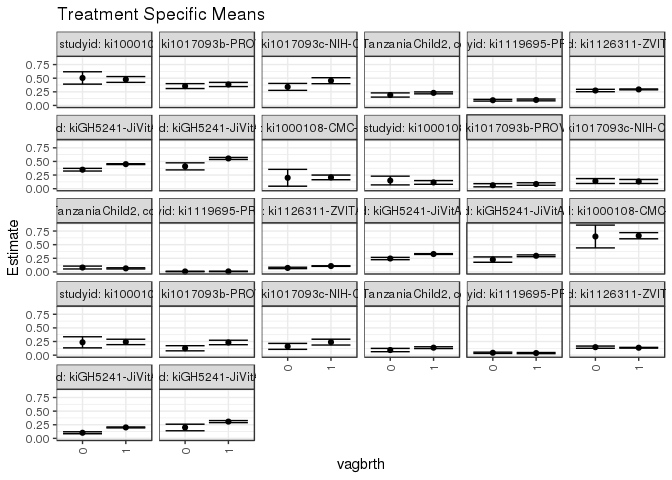

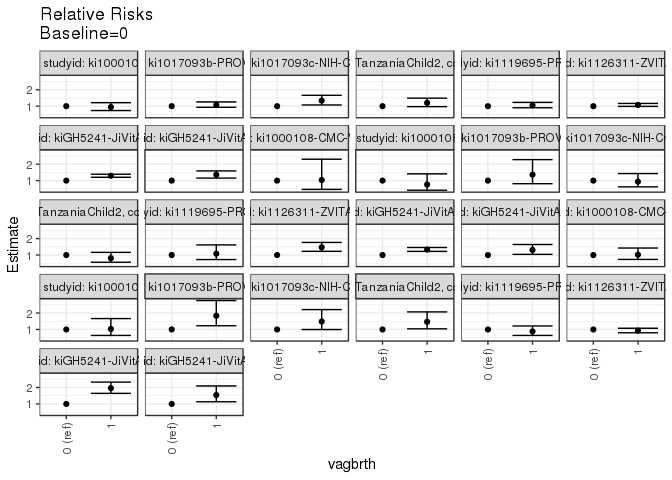

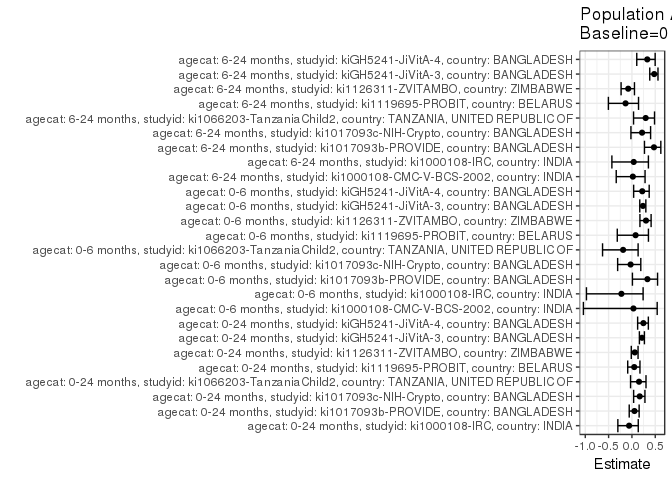

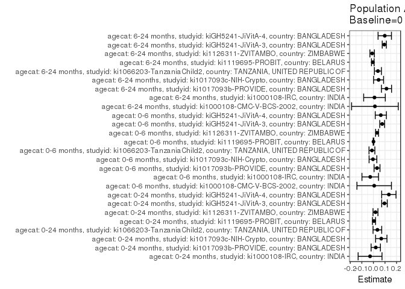

## Results Table

### Parameter: TSM

| agecat | studyid | country | intervention_level | baseline_level | estimate | ci_lower | ci_upper |
| --- | --- | --- | --- | --- | --- | --- | --- |
| 0-24 months | ki1000108-IRC | INDIA | 0 | NA | 0.5045188 | 0.3913168 | 0.6177208 |
| 0-24 months | ki1000108-IRC | INDIA | 1 | NA | 0.4767617 | 0.4237731 | 0.5297503 |
| 0-24 months | ki1017093b-PROVIDE | BANGLADESH | 0 | NA | 0.3553864 | 0.3103792 | 0.4003937 |
| 0-24 months | ki1017093b-PROVIDE | BANGLADESH | 1 | NA | 0.3847226 | 0.3462883 | 0.4231568 |
| 0-24 months | ki1017093c-NIH-Crypto | BANGLADESH | 0 | NA | 0.3401385 | 0.2765488 | 0.4037281 |
| 0-24 months | ki1017093c-NIH-Crypto | BANGLADESH | 1 | NA | 0.4543359 | 0.3990871 | 0.5095848 |
| 0-24 months | ki1066203-TanzaniaChild2 | TANZANIA, UNITED REPUBLIC OF | 0 | NA | 0.1916894 | 0.1531616 | 0.2302172 |
| 0-24 months | ki1066203-TanzaniaChild2 | TANZANIA, UNITED REPUBLIC OF | 1 | NA | 0.2305511 | 0.2129450 | 0.2481573 |
| 0-24 months | ki1119695-PROBIT | BELARUS | 0 | NA | 0.0956034 | 0.0796354 | 0.1115714 |
| 0-24 months | ki1119695-PROBIT | BELARUS | 1 | NA | 0.1008538 | 0.0846129 | 0.1170947 |
| 0-24 months | ki1126311-ZVITAMBO | ZIMBABWE | 0 | NA | 0.2739896 | 0.2519590 | 0.2960201 |
| 0-24 months | ki1126311-ZVITAMBO | ZIMBABWE | 1 | NA | 0.2941076 | 0.2862383 | 0.3019770 |
| 0-24 months | kiGH5241-JiVitA-3 | BANGLADESH | 0 | NA | 0.3481407 | 0.3236899 | 0.3725914 |
| 0-24 months | kiGH5241-JiVitA-3 | BANGLADESH | 1 | NA | 0.4501239 | 0.4424890 | 0.4577588 |
| 0-24 months | kiGH5241-JiVitA-4 | BANGLADESH | 0 | NA | 0.4095148 | 0.3449899 | 0.4740396 |
| 0-24 months | kiGH5241-JiVitA-4 | BANGLADESH | 1 | NA | 0.5546597 | 0.5362189 | 0.5731006 |
| 0-6 months | ki1000108-CMC-V-BCS-2002 | INDIA | 0 | NA | 0.1998007 | 0.0453884 | 0.3542131 |
| 0-6 months | ki1000108-CMC-V-BCS-2002 | INDIA | 1 | NA | 0.2068439 | 0.1639659 | 0.2497220 |
| 0-6 months | ki1000108-IRC | INDIA | 0 | NA | 0.1494680 | 0.0689381 | 0.2299979 |
| 0-6 months | ki1000108-IRC | INDIA | 1 | NA | 0.1142945 | 0.0805167 | 0.1480722 |
| 0-6 months | ki1017093b-PROVIDE | BANGLADESH | 0 | NA | 0.0629771 | 0.0339019 | 0.0920522 |
| 0-6 months | ki1017093b-PROVIDE | BANGLADESH | 1 | NA | 0.0857030 | 0.0630048 | 0.1084012 |
| 0-6 months | ki1017093c-NIH-Crypto | BANGLADESH | 0 | NA | 0.1398998 | 0.0947159 | 0.1850837 |
| 0-6 months | ki1017093c-NIH-Crypto | BANGLADESH | 1 | NA | 0.1318577 | 0.0946873 | 0.1690281 |
| 0-6 months | ki1066203-TanzaniaChild2 | TANZANIA, UNITED REPUBLIC OF | 0 | NA | 0.0803824 | 0.0538407 | 0.1069241 |
| 0-6 months | ki1066203-TanzaniaChild2 | TANZANIA, UNITED REPUBLIC OF | 1 | NA | 0.0650885 | 0.0547563 | 0.0754207 |
| 0-6 months | ki1119695-PROBIT | BELARUS | 0 | NA | 0.0083474 | 0.0043628 | 0.0123320 |
| 0-6 months | ki1119695-PROBIT | BELARUS | 1 | NA | 0.0090412 | 0.0058292 | 0.0122532 |
| 0-6 months | ki1126311-ZVITAMBO | ZIMBABWE | 0 | NA | 0.0730271 | 0.0601945 | 0.0858597 |
| 0-6 months | ki1126311-ZVITAMBO | ZIMBABWE | 1 | NA | 0.1074804 | 0.1021211 | 0.1128397 |
| 0-6 months | kiGH5241-JiVitA-3 | BANGLADESH | 0 | NA | 0.2457544 | 0.2244267 | 0.2670822 |
| 0-6 months | kiGH5241-JiVitA-3 | BANGLADESH | 1 | NA | 0.3281507 | 0.3211832 | 0.3351182 |
| 0-6 months | kiGH5241-JiVitA-4 | BANGLADESH | 0 | NA | 0.2258378 | 0.1769093 | 0.2747662 |
| 0-6 months | kiGH5241-JiVitA-4 | BANGLADESH | 1 | NA | 0.2954969 | 0.2792112 | 0.3117825 |
| 6-24 months | ki1000108-CMC-V-BCS-2002 | INDIA | 0 | NA | 0.6500265 | 0.4408822 | 0.8591707 |
| 6-24 months | ki1000108-CMC-V-BCS-2002 | INDIA | 1 | NA | 0.6641677 | 0.6075303 | 0.7208051 |
| 6-24 months | ki1000108-IRC | INDIA | 0 | NA | 0.2354874 | 0.1333841 | 0.3375907 |
| 6-24 months | ki1000108-IRC | INDIA | 1 | NA | 0.2425654 | 0.1927540 | 0.2923767 |
| 6-24 months | ki1017093b-PROVIDE | BANGLADESH | 0 | NA | 0.1263612 | 0.0793970 | 0.1733253 |
| 6-24 months | ki1017093b-PROVIDE | BANGLADESH | 1 | NA | 0.2323791 | 0.1913396 | 0.2734186 |
| 6-24 months | ki1017093c-NIH-Crypto | BANGLADESH | 0 | NA | 0.1609443 | 0.1065478 | 0.2153408 |
| 6-24 months | ki1017093c-NIH-Crypto | BANGLADESH | 1 | NA | 0.2388305 | 0.1851390 | 0.2925219 |
| 6-24 months | ki1066203-TanzaniaChild2 | TANZANIA, UNITED REPUBLIC OF | 0 | NA | 0.0934891 | 0.0631731 | 0.1238052 |
| 6-24 months | ki1066203-TanzaniaChild2 | TANZANIA, UNITED REPUBLIC OF | 1 | NA | 0.1369629 | 0.1205351 | 0.1533908 |
| 6-24 months | ki1119695-PROBIT | BELARUS | 0 | NA | 0.0432257 | 0.0320726 | 0.0543788 |
| 6-24 months | ki1119695-PROBIT | BELARUS | 1 | NA | 0.0380339 | 0.0279284 | 0.0481393 |
| 6-24 months | ki1126311-ZVITAMBO | ZIMBABWE | 0 | NA | 0.1464276 | 0.1262599 | 0.1665953 |
| 6-24 months | ki1126311-ZVITAMBO | ZIMBABWE | 1 | NA | 0.1357311 | 0.1284566 | 0.1430055 |
| 6-24 months | kiGH5241-JiVitA-3 | BANGLADESH | 0 | NA | 0.1029188 | 0.0853030 | 0.1205346 |
| 6-24 months | kiGH5241-JiVitA-3 | BANGLADESH | 1 | NA | 0.2009952 | 0.1927015 | 0.2092888 |
| 6-24 months | kiGH5241-JiVitA-4 | BANGLADESH | 0 | NA | 0.2000710 | 0.1398769 | 0.2602651 |
| 6-24 months | kiGH5241-JiVitA-4 | BANGLADESH | 1 | NA | 0.3078771 | 0.2887764 | 0.3269779 |

### Parameter: E(Y)

| agecat | studyid | country | intervention_level | baseline_level | estimate | ci_lower | ci_upper |
| --- | --- | --- | --- | --- | --- | --- | --- |
| 0-24 months | ki1000108-IRC | INDIA | NA | NA | 0.4756098 | 0.4272105 | 0.5240091 |
| 0-24 months | ki1017093b-PROVIDE | BANGLADESH | NA | NA | 0.3757143 | 0.3398113 | 0.4116172 |
| 0-24 months | ki1017093c-NIH-Crypto | BANGLADESH | NA | NA | 0.4080000 | 0.3648790 | 0.4511210 |
| 0-24 months | ki1066203-TanzaniaChild2 | TANZANIA, UNITED REPUBLIC OF | NA | NA | 0.2260245 | 0.2091713 | 0.2428777 |
| 0-24 months | ki1119695-PROBIT | BELARUS | NA | NA | 0.1006096 | 0.0848963 | 0.1163228 |
| 0-24 months | ki1126311-ZVITAMBO | ZIMBABWE | NA | NA | 0.2918756 | 0.2843333 | 0.2994180 |
| 0-24 months | kiGH5241-JiVitA-3 | BANGLADESH | NA | NA | 0.4437641 | 0.4362380 | 0.4512902 |
| 0-24 months | kiGH5241-JiVitA-4 | BANGLADESH | NA | NA | 0.5429204 | 0.5251795 | 0.5606613 |
| 0-6 months | ki1000108-CMC-V-BCS-2002 | INDIA | NA | NA | 0.2065217 | 0.1651060 | 0.2479375 |
| 0-6 months | ki1000108-IRC | INDIA | NA | NA | 0.1219512 | 0.0902381 | 0.1536643 |
| 0-6 months | ki1017093b-PROVIDE | BANGLADESH | NA | NA | 0.0942857 | 0.0726222 | 0.1159492 |
| 0-6 months | ki1017093c-NIH-Crypto | BANGLADESH | NA | NA | 0.1360000 | 0.1059237 | 0.1660763 |
| 0-6 months | ki1066203-TanzaniaChild2 | TANZANIA, UNITED REPUBLIC OF | NA | NA | 0.0675961 | 0.0574802 | 0.0777120 |
| 0-6 months | ki1119695-PROBIT | BELARUS | NA | NA | 0.0090570 | 0.0059070 | 0.0122070 |
| 0-6 months | ki1126311-ZVITAMBO | ZIMBABWE | NA | NA | 0.1045419 | 0.0994621 | 0.1096217 |
| 0-6 months | kiGH5241-JiVitA-3 | BANGLADESH | NA | NA | 0.3215815 | 0.3148000 | 0.3283630 |
| 0-6 months | kiGH5241-JiVitA-4 | BANGLADESH | NA | NA | 0.2898358 | 0.2745243 | 0.3051473 |
| 6-24 months | ki1000108-CMC-V-BCS-2002 | INDIA | NA | NA | 0.6631944 | 0.6085159 | 0.7178730 |
| 6-24 months | ki1000108-IRC | INDIA | NA | NA | 0.2448378 | 0.1989973 | 0.2906782 |
| 6-24 months | ki1017093b-PROVIDE | BANGLADESH | NA | NA | 0.2394366 | 0.2018814 | 0.2769918 |
| 6-24 months | ki1017093c-NIH-Crypto | BANGLADESH | NA | NA | 0.2055838 | 0.1656288 | 0.2455387 |
| 6-24 months | ki1066203-TanzaniaChild2 | TANZANIA, UNITED REPUBLIC OF | NA | NA | 0.1325301 | 0.1169740 | 0.1480862 |
| 6-24 months | ki1119695-PROBIT | BELARUS | NA | NA | 0.0380298 | 0.0285924 | 0.0474672 |
| 6-24 months | ki1126311-ZVITAMBO | ZIMBABWE | NA | NA | 0.1356207 | 0.1286388 | 0.1426026 |
| 6-24 months | kiGH5241-JiVitA-3 | BANGLADESH | NA | NA | 0.1969628 | 0.1889381 | 0.2049875 |
| 6-24 months | kiGH5241-JiVitA-4 | BANGLADESH | NA | NA | 0.2981575 | 0.2800007 | 0.3163142 |

### Parameter: RR

| agecat | studyid | country | intervention_level | baseline_level | estimate | ci_lower | ci_upper |
| --- | --- | --- | --- | --- | --- | --- | --- |
| 0-24 months | ki1000108-IRC | INDIA | 0 | 0 | 1.0000000 | 1.0000000 | 1.000000 |
| 0-24 months | ki1000108-IRC | INDIA | 1 | 0 | 0.9449830 | 0.7359174 | 1.213442 |
| 0-24 months | ki1017093b-PROVIDE | BANGLADESH | 0 | 0 | 1.0000000 | 1.0000000 | 1.000000 |
| 0-24 months | ki1017093b-PROVIDE | BANGLADESH | 1 | 0 | 1.0825472 | 0.9312673 | 1.258402 |
| 0-24 months | ki1017093c-NIH-Crypto | BANGLADESH | 0 | 0 | 1.0000000 | 1.0000000 | 1.000000 |
| 0-24 months | ki1017093c-NIH-Crypto | BANGLADESH | 1 | 0 | 1.3357382 | 1.0731203 | 1.662625 |
| 0-24 months | ki1066203-TanzaniaChild2 | TANZANIA, UNITED REPUBLIC OF | 0 | 0 | 1.0000000 | 1.0000000 | 1.000000 |
| 0-24 months | ki1066203-TanzaniaChild2 | TANZANIA, UNITED REPUBLIC OF | 1 | 0 | 1.2027329 | 0.9717125 | 1.488678 |
| 0-24 months | ki1119695-PROBIT | BELARUS | 0 | 0 | 1.0000000 | 1.0000000 | 1.000000 |
| 0-24 months | ki1119695-PROBIT | BELARUS | 1 | 0 | 1.0549188 | 0.9046399 | 1.230162 |
| 0-24 months | ki1126311-ZVITAMBO | ZIMBABWE | 0 | 0 | 1.0000000 | 1.0000000 | 1.000000 |
| 0-24 months | ki1126311-ZVITAMBO | ZIMBABWE | 1 | 0 | 1.0734264 | 0.9865087 | 1.168002 |
| 0-24 months | kiGH5241-JiVitA-3 | BANGLADESH | 0 | 0 | 1.0000000 | 1.0000000 | 1.000000 |
| 0-24 months | kiGH5241-JiVitA-3 | BANGLADESH | 1 | 0 | 1.2929369 | 1.2037325 | 1.388752 |
| 0-24 months | kiGH5241-JiVitA-4 | BANGLADESH | 0 | 0 | 1.0000000 | 1.0000000 | 1.000000 |
| 0-24 months | kiGH5241-JiVitA-4 | BANGLADESH | 1 | 0 | 1.3544316 | 1.1527985 | 1.591332 |
| 0-6 months | ki1000108-CMC-V-BCS-2002 | INDIA | 0 | 0 | 1.0000000 | 1.0000000 | 1.000000 |
| 0-6 months | ki1000108-CMC-V-BCS-2002 | INDIA | 1 | 0 | 1.0352511 | 0.4655280 | 2.302214 |
| 0-6 months | ki1000108-IRC | INDIA | 0 | 0 | 1.0000000 | 1.0000000 | 1.000000 |
| 0-6 months | ki1000108-IRC | INDIA | 1 | 0 | 0.7646750 | 0.4143839 | 1.411078 |
| 0-6 months | ki1017093b-PROVIDE | BANGLADESH | 0 | 0 | 1.0000000 | 1.0000000 | 1.000000 |
| 0-6 months | ki1017093b-PROVIDE | BANGLADESH | 1 | 0 | 1.3608601 | 0.8132912 | 2.277093 |
| 0-6 months | ki1017093c-NIH-Crypto | BANGLADESH | 0 | 0 | 1.0000000 | 1.0000000 | 1.000000 |
| 0-6 months | ki1017093c-NIH-Crypto | BANGLADESH | 1 | 0 | 0.9425150 | 0.6216169 | 1.429071 |
| 0-6 months | ki1066203-TanzaniaChild2 | TANZANIA, UNITED REPUBLIC OF | 0 | 0 | 1.0000000 | 1.0000000 | 1.000000 |
| 0-6 months | ki1066203-TanzaniaChild2 | TANZANIA, UNITED REPUBLIC OF | 1 | 0 | 0.8097353 | 0.5633018 | 1.163979 |
| 0-6 months | ki1119695-PROBIT | BELARUS | 0 | 0 | 1.0000000 | 1.0000000 | 1.000000 |
| 0-6 months | ki1119695-PROBIT | BELARUS | 1 | 0 | 1.0831203 | 0.7256155 | 1.616765 |
| 0-6 months | ki1126311-ZVITAMBO | ZIMBABWE | 0 | 0 | 1.0000000 | 1.0000000 | 1.000000 |
| 0-6 months | ki1126311-ZVITAMBO | ZIMBABWE | 1 | 0 | 1.4717886 | 1.2262728 | 1.766460 |
| 0-6 months | kiGH5241-JiVitA-3 | BANGLADESH | 0 | 0 | 1.0000000 | 1.0000000 | 1.000000 |
| 0-6 months | kiGH5241-JiVitA-3 | BANGLADESH | 1 | 0 | 1.3352791 | 1.2220832 | 1.458960 |
| 0-6 months | kiGH5241-JiVitA-4 | BANGLADESH | 0 | 0 | 1.0000000 | 1.0000000 | 1.000000 |
| 0-6 months | kiGH5241-JiVitA-4 | BANGLADESH | 1 | 0 | 1.3084476 | 1.0425739 | 1.642124 |
| 6-24 months | ki1000108-CMC-V-BCS-2002 | INDIA | 0 | 0 | 1.0000000 | 1.0000000 | 1.000000 |
| 6-24 months | ki1000108-CMC-V-BCS-2002 | INDIA | 1 | 0 | 1.0217549 | 0.7324868 | 1.425258 |
| 6-24 months | ki1000108-IRC | INDIA | 0 | 0 | 1.0000000 | 1.0000000 | 1.000000 |
| 6-24 months | ki1000108-IRC | INDIA | 1 | 0 | 1.0300567 | 0.6376834 | 1.663861 |
| 6-24 months | ki1017093b-PROVIDE | BANGLADESH | 0 | 0 | 1.0000000 | 1.0000000 | 1.000000 |
| 6-24 months | ki1017093b-PROVIDE | BANGLADESH | 1 | 0 | 1.8390069 | 1.2250602 | 2.760637 |
| 6-24 months | ki1017093c-NIH-Crypto | BANGLADESH | 0 | 0 | 1.0000000 | 1.0000000 | 1.000000 |
| 6-24 months | ki1017093c-NIH-Crypto | BANGLADESH | 1 | 0 | 1.4839326 | 0.9971533 | 2.208342 |
| 6-24 months | ki1066203-TanzaniaChild2 | TANZANIA, UNITED REPUBLIC OF | 0 | 0 | 1.0000000 | 1.0000000 | 1.000000 |
| 6-24 months | ki1066203-TanzaniaChild2 | TANZANIA, UNITED REPUBLIC OF | 1 | 0 | 1.4650146 | 1.0379529 | 2.067789 |
| 6-24 months | ki1119695-PROBIT | BELARUS | 0 | 0 | 1.0000000 | 1.0000000 | 1.000000 |
| 6-24 months | ki1119695-PROBIT | BELARUS | 1 | 0 | 0.8798907 | 0.6380109 | 1.213471 |
| 6-24 months | ki1126311-ZVITAMBO | ZIMBABWE | 0 | 0 | 1.0000000 | 1.0000000 | 1.000000 |
| 6-24 months | ki1126311-ZVITAMBO | ZIMBABWE | 1 | 0 | 0.9269499 | 0.8000588 | 1.073966 |
| 6-24 months | kiGH5241-JiVitA-3 | BANGLADESH | 0 | 0 | 1.0000000 | 1.0000000 | 1.000000 |
| 6-24 months | kiGH5241-JiVitA-3 | BANGLADESH | 1 | 0 | 1.9529486 | 1.6400050 | 2.325608 |
| 6-24 months | kiGH5241-JiVitA-4 | BANGLADESH | 0 | 0 | 1.0000000 | 1.0000000 | 1.000000 |
| 6-24 months | kiGH5241-JiVitA-4 | BANGLADESH | 1 | 0 | 1.5388392 | 1.1313478 | 2.093102 |

### Parameter: PAR

| agecat | studyid | country | intervention_level | baseline_level | estimate | ci_lower | ci_upper |
| --- | --- | --- | --- | --- | --- | --- | --- |
| 0-24 months | ki1000108-IRC | INDIA | 0 | NA | -0.0289090 | -0.1320993 | 0.0742812 |
| 0-24 months | ki1017093b-PROVIDE | BANGLADESH | 0 | NA | 0.0203279 | -0.0200799 | 0.0607357 |
| 0-24 months | ki1017093c-NIH-Crypto | BANGLADESH | 0 | NA | 0.0678615 | 0.0187605 | 0.1169626 |
| 0-24 months | ki1066203-TanzaniaChild2 | TANZANIA, UNITED REPUBLIC OF | 0 | NA | 0.0343351 | -0.0031535 | 0.0718237 |
| 0-24 months | ki1119695-PROBIT | BELARUS | 0 | NA | 0.0050062 | -0.0084496 | 0.0184619 |
| 0-24 months | ki1126311-ZVITAMBO | ZIMBABWE | 0 | NA | 0.0178861 | -0.0033060 | 0.0390782 |
| 0-24 months | kiGH5241-JiVitA-3 | BANGLADESH | 0 | NA | 0.0956234 | 0.0716272 | 0.1196196 |
| 0-24 months | kiGH5241-JiVitA-4 | BANGLADESH | 0 | NA | 0.1334056 | 0.0715215 | 0.1952897 |
| 0-6 months | ki1000108-CMC-V-BCS-2002 | INDIA | 0 | NA | 0.0067210 | -0.1423559 | 0.1557979 |
| 0-6 months | ki1000108-IRC | INDIA | 0 | NA | -0.0275168 | -0.0990450 | 0.0440114 |
| 0-6 months | ki1017093b-PROVIDE | BANGLADESH | 0 | NA | 0.0313086 | 0.0057636 | 0.0568537 |
| 0-6 months | ki1017093c-NIH-Crypto | BANGLADESH | 0 | NA | -0.0038998 | -0.0373121 | 0.0295125 |
| 0-6 months | ki1066203-TanzaniaChild2 | TANZANIA, UNITED REPUBLIC OF | 0 | NA | -0.0127863 | -0.0379370 | 0.0123644 |
| 0-6 months | ki1119695-PROBIT | BELARUS | 0 | NA | 0.0007096 | -0.0022813 | 0.0037006 |
| 0-6 months | ki1126311-ZVITAMBO | ZIMBABWE | 0 | NA | 0.0315148 | 0.0189107 | 0.0441189 |
| 0-6 months | kiGH5241-JiVitA-3 | BANGLADESH | 0 | NA | 0.0758271 | 0.0547783 | 0.0968759 |
| 0-6 months | kiGH5241-JiVitA-4 | BANGLADESH | 0 | NA | 0.0639980 | 0.0158281 | 0.1121679 |
| 6-24 months | ki1000108-CMC-V-BCS-2002 | INDIA | 0 | NA | 0.0131680 | -0.1884351 | 0.2147710 |
| 6-24 months | ki1000108-IRC | INDIA | 0 | NA | 0.0093504 | -0.0840663 | 0.1027670 |
| 6-24 months | ki1017093b-PROVIDE | BANGLADESH | 0 | NA | 0.1130754 | 0.0693253 | 0.1568256 |
| 6-24 months | ki1017093c-NIH-Crypto | BANGLADESH | 0 | NA | 0.0446395 | 0.0014194 | 0.0878595 |
| 6-24 months | ki1066203-TanzaniaChild2 | TANZANIA, UNITED REPUBLIC OF | 0 | NA | 0.0390410 | 0.0089345 | 0.0691475 |
| 6-24 months | ki1119695-PROBIT | BELARUS | 0 | NA | -0.0051959 | -0.0166887 | 0.0062970 |
| 6-24 months | ki1126311-ZVITAMBO | ZIMBABWE | 0 | NA | -0.0108069 | -0.0301502 | 0.0085365 |
| 6-24 months | kiGH5241-JiVitA-3 | BANGLADESH | 0 | NA | 0.0940440 | 0.0761865 | 0.1119016 |
| 6-24 months | kiGH5241-JiVitA-4 | BANGLADESH | 0 | NA | 0.0980864 | 0.0402496 | 0.1559232 |

### Parameter: PAF

| agecat | studyid | country | intervention_level | baseline_level | estimate | ci_lower | ci_upper |
| --- | --- | --- | --- | --- | --- | --- | --- |
| 0-24 months | ki1000108-IRC | INDIA | 0 | NA | -0.0607831 | -0.3017704 | 0.1355920 |
| 0-24 months | ki1017093b-PROVIDE | BANGLADESH | 0 | NA | 0.0541046 | -0.0581374 | 0.1544405 |
| 0-24 months | ki1017093c-NIH-Crypto | BANGLADESH | 0 | NA | 0.1663273 | 0.0364662 | 0.2786863 |
| 0-24 months | ki1066203-TanzaniaChild2 | TANZANIA, UNITED REPUBLIC OF | 0 | NA | 0.1519088 | -0.0295109 | 0.3013588 |
| 0-24 months | ki1119695-PROBIT | BELARUS | 0 | NA | 0.0497586 | -0.0904203 | 0.1719167 |
| 0-24 months | ki1126311-ZVITAMBO | ZIMBABWE | 0 | NA | 0.0612798 | -0.0141167 | 0.1310708 |
| 0-24 months | kiGH5241-JiVitA-3 | BANGLADESH | 0 | NA | 0.2154825 | 0.1597447 | 0.2675231 |
| 0-24 months | kiGH5241-JiVitA-4 | BANGLADESH | 0 | NA | 0.2457186 | 0.1222622 | 0.3518104 |
| 0-6 months | ki1000108-CMC-V-BCS-2002 | INDIA | 0 | NA | 0.0325438 | -1.0401444 | 0.5412229 |
| 0-6 months | ki1000108-IRC | INDIA | 0 | NA | -0.2256376 | -0.9750119 | 0.2394033 |
| 0-6 months | ki1017093b-PROVIDE | BANGLADESH | 0 | NA | 0.3320612 | 0.0105278 | 0.5491109 |
| 0-6 months | ki1017093c-NIH-Crypto | BANGLADESH | 0 | NA | -0.0286752 | -0.3061947 | 0.1898814 |
| 0-6 months | ki1066203-TanzaniaChild2 | TANZANIA, UNITED REPUBLIC OF | 0 | NA | -0.1891577 | -0.6297936 | 0.1323466 |
| 0-6 months | ki1119695-PROBIT | BELARUS | 0 | NA | 0.0783518 | -0.3142016 | 0.3536491 |
| 0-6 months | ki1126311-ZVITAMBO | ZIMBABWE | 0 | NA | 0.3014563 | 0.1715301 | 0.4110066 |
| 0-6 months | kiGH5241-JiVitA-3 | BANGLADESH | 0 | NA | 0.2357943 | 0.1678993 | 0.2981495 |
| 0-6 months | kiGH5241-JiVitA-4 | BANGLADESH | 0 | NA | 0.2208079 | 0.0366252 | 0.3697776 |
| 6-24 months | ki1000108-CMC-V-BCS-2002 | INDIA | 0 | NA | 0.0198554 | -0.3365657 | 0.2812299 |
| 6-24 months | ki1000108-IRC | INDIA | 0 | NA | 0.0381900 | -0.4297168 | 0.3529638 |
| 6-24 months | ki1017093b-PROVIDE | BANGLADESH | 0 | NA | 0.4722562 | 0.2686221 | 0.6191934 |
| 6-24 months | ki1017093c-NIH-Crypto | BANGLADESH | 0 | NA | 0.2171352 | -0.0214833 | 0.4000125 |
| 6-24 months | ki1066203-TanzaniaChild2 | TANZANIA, UNITED REPUBLIC OF | 0 | NA | 0.2945820 | 0.0346958 | 0.4844997 |
| 6-24 months | ki1119695-PROBIT | BELARUS | 0 | NA | -0.1366266 | -0.5045949 | 0.1413503 |
| 6-24 months | ki1126311-ZVITAMBO | ZIMBABWE | 0 | NA | -0.0796845 | -0.2325098 | 0.0541912 |
| 6-24 months | kiGH5241-JiVitA-3 | BANGLADESH | 0 | NA | 0.4774708 | 0.3819202 | 0.5582500 |
| 6-24 months | kiGH5241-JiVitA-4 | BANGLADESH | 0 | NA | 0.3289753 | 0.1033221 | 0.4978418 |